# Informe Técnico: Red Neuronal Déficit Habitacional

Felipe Segovia y Tomás Urrutia

2026-01-08

## 1. Introducción y Carga de Datos

En esta sección se procede a la carga de la base de datos consolidada, la cual integra información socioeconómica (CASEN 2022) con indicadores territoriales del MINVU.

Se aplica un filtro metodológico crítico para establecer la **unidad de análisis correcta**, asegurando la independencia de las observaciones.

```r
library(tidyverse)
library(caret)
library(haven) # IMPORTANTE: Para manejar las etiquetas de la CASEN

# 1. Carga de la base maestra
# Verificamos si existe el archivo para evitar errores
if(file.exists("Base_Final_Tesis_Definitiva.rds")) {
  df_completo <- readRDS("Base_Final_Tesis_Definitiva.rds")
} else {
  stop("Error: No se encuentra el archivo 'Base_Final_Tesis_Definitiva.rds'.")
}

# 2. CORRECCIÓN MUESTRAL: INDEPENDENCIA DE OBSERVACIONES
# Se filtra la base para conservar un solo registro por Hogar (Folio),
# eliminando la duplicidad generada por los múltiples integrantes.
df_hogares <- df_completo %>%
  distinct(folio, .keep_all = TRUE)

# 3. Reporte de reducción muestral
print(paste("Muestra inicial (Individuos):", nrow(df_completo)))
```

```
## [1] "Muestra inicial (Individuos): 202231"
```

```r
print(paste("Muestra ajustada (Hogares únicos):", nrow(df_hogares)))
```

```
## [1] "Muestra ajustada (Hogares únicos): 72056"
```

## 2. Selección de Variables

Se seleccionan las variables predictoras basándose en la literatura económica y se normalizan los datos para el correcto funcionamiento del algoritmo de Deep Learning.

- **Target:** `CLASE` (0 = Sin Déficit, 2 = Déficit Crítico).
- **Predictores:** Ingreso, Escolaridad, Tamaño del Hogar, Déficit Comunal (MINVU) y Hacinamiento.

```r
# LIMPIEZA DE ETIQUETAS
# Convertimos todas las variables 'haven_labelled' a números puros
df_hogares_clean <- df_hogares %>%
  haven::zap_labels()

# Selección y transformación de variables
datos_modelo <- df_hogares_clean %>%
  select(
    CLASE,
    yautcor,                    # Ingreso Autónomo
    tot_per_h,                  # Tamaño del Hogar
    esc,                        # Escolaridad del Jefe
    edad,                       # Edad
    sexo,                       # Sexo
    deficit_cuantitativo_total, # Variable Contextual (MINVU)
    ind_hacina                  # Índice de Hacinamiento
  ) %>%
  mutate(
    # Ahora sí podemos convertir sin errores
    CLASE = factor(ifelse(CLASE == 2, "DEFICIT", "SANO")),
    sexo = as.numeric(sexo)
  ) %>%
  na.omit() # Eliminación de casos incompletos

# Visualización de la distribución de clases
print("Distribución de clases (Antes del balanceo):")
```

```
## [1] "Distribución de clases (Antes del balanceo):"
```

```r
table(datos_modelo$CLASE)
```

```
##
## DEFICIT    SANO
##    3468   52878
```

## 3. Entrenamiento del Modelo (Red Neuronal)

Se implementa un **Perceptrón Multicapa (MLP)** utilizando la librería `caret`.

### Metodología de Entrenamiento:

1. **Validación Cruzada (k-fold CV):** $k=5$ para asegurar robustez estadística.
2. **Balanceo de Clases (Up-Sampling):** Dado el desbalance natural del déficit habitacional, se aplica sobremuestreo a la clase minoritaria (“DEFICIT”) durante el entrenamiento. Esto permite que el modelo aprenda a detectar casos críticos con mayor sensibilidad.
3. **Preprocesamiento:** Centrado y escalado (Z-score) de todas las variables numéricas.

```r
# Separación Train/Test (70% - 30%)
set.seed(123)
indice_train <- createDataPartition(datos_modelo$CLASE, p = 0.7, list = FALSE)
train_data <- datos_modelo[indice_train, ]
test_data  <- datos_modelo[-indice_train, ]

# Configuración de control
control_entrenamiento <- trainControl(
  method = "cv",
  number = 5,
  classProbs = TRUE,
  summaryFunction = twoClassSummary, # Optimizar ROC
  sampling = "up",      # Balanceo de clases
  verboseIter = FALSE
)

# Entrenamiento (nnet)
modelo_nn <- train(
  CLASE ~ .,
  data = train_data,
  method = "nnet",
  trControl = control_entrenamiento,
  preProcess = c("center", "scale"),
  trace = FALSE,
  tuneLength = 5,
  metric = "ROC"
)

# Resultados del entrenamiento
print(modelo_nn)
```

```
## Neural Network
##
## 39443 samples
##     7 predictor
##     2 classes: 'DEFICIT', 'SANO'
##
## Pre-processing: centered (7), scaled (7)
## Resampling: Cross-Validated (5 fold)
## Summary of sample sizes: 31555, 31554, 31555, 31554, 31554
## Addtional sampling using up-sampling prior to pre-processing
##
## Resampling results across tuning parameters:
##
##   size  decay  ROC        Sens       Spec
##   1     0e+00  0.8500871  0.6210980  0.9614751
##   1     1e-04  0.8460533  0.6149243  0.9642307
##   1     1e-03  0.8423129  0.6186119  0.9603134
##   1     1e-02  0.8588453  0.6260354  0.9539916
##   1     1e-01  0.8585408  0.6248000  0.9555586
##   3     0e+00  0.8619319  0.6425014  0.9385654
##   3     1e-04  0.8583952  0.6342692  0.9438606
##   3     1e-03  0.8614241  0.6437648  0.9301364
##   3     1e-02  0.8652397  0.6560994  0.9268405
##   3     1e-01  0.8646047  0.6470587  0.9349453
##   5     0e+00  0.8609795  0.6585771  0.9125490
##   5     1e-04  0.8628562  0.6688685  0.9071458
##   5     1e-03  0.8581634  0.6552789  0.9182494
##   5     1e-02  0.8621020  0.6548640  0.9167094
##   5     1e-01  0.8621995  0.6519885  0.9255167
##   7     0e+00  0.8642614  0.6610496  0.9214913
##   7     1e-04  0.8620662  0.6565127  0.9191139
##   7     1e-03  0.8616649  0.6552934  0.9152776
##   7     1e-02  0.8630593  0.6688821  0.9134675
##   7     1e-01  0.8627545  0.6606381  0.9192219
##   9     0e+00  0.8621010  0.6561096  0.9192490
##   9     1e-04  0.8587631  0.6635119  0.9126840
##   9     1e-03  0.8576292  0.6581528  0.9163312
##   9     1e-02  0.8609034  0.6622774  0.9127651
##   9     1e-01  0.8624343  0.6536269  0.9193030
##
## ROC was used to select the optimal model using the largest value.
## The final values used for the model were size = 3 and decay = 0.01.
```

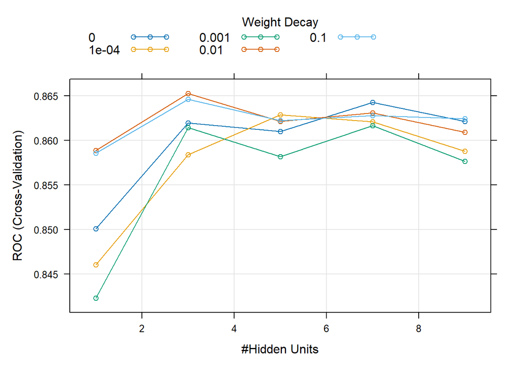

```r
plot(modelo_nn)
```

## 4. Evaluación de Desempeño

Se evalúa el modelo con el conjunto de prueba (Test Set, 30%) que no fue visto durante el entrenamiento para garantizar una evaluación honesta.

### 4.1. Matriz de Confusión

Permite visualizar la capacidad del modelo para distinguir Verdaderos Positivos (Déficit real) y calcular métricas como Sensibilidad y Especificidad.

```r
# Predicciones
predicciones_raw <- predict(modelo_nn, test_data)

# Métricas detalladas
conf_matrix <- confusionMatrix(predicciones_raw, test_data$CLASE, mode = "everything")
print(conf_matrix)
```

```
## Confusion Matrix and Statistics
##
##           Reference
## Prediction DEFICIT  SANO
##    DEFICIT     688  1023
##    SANO        352 14840
##
##                Accuracy : 0.9187
##                  95% CI : (0.9144, 0.9227)
##     No Information Rate : 0.9385
##     P-Value [Acc > NIR] : 1
##
##                   Kappa : 0.4588
##
##  Mcnemar's Test P-Value : <2e-16
##
##             Sensitivity : 0.66154
##             Specificity : 0.93551
##          Pos Pred Value : 0.40210
##          Neg Pred Value : 0.97683
##               Precision : 0.40210
##                  Recall : 0.66154
##                      F1 : 0.50018
##              Prevalence : 0.06153
##          Detection Rate : 0.04070
##    Detection Prevalence : 0.10122
##       Balanced Accuracy : 0.79852
##
##        'Positive' Class : DEFICIT
##
```